# Final Project - Rajagopal - draft 1

Advait Rajagopal

December 13, 2017

## Research Objective

- The goal of this project is to study the borrowing and lending behavior in villages in Karnataka.
- The network dataset is compiled by “Abdul Latif Jameel Poverty Action Lab” that is located in the economics department at MIT. It is a network dataset that contains relational data about borrowing, lending, social activities and other behavioral patterns. It also has demographic data that includes information about occupation, religion, caste, education, migration patterns and a lot more.There is information about 77 villages, containing household level information and individual level information.
- Limitations of the data are symmetric adjacency matrices (undirected) for all questions and missing data at the individual (person) node level.

```r
#rm(list = ls())
library(statnet)
library(ergm)
library(foreign)
library(Bergm)
```

I have selected village 74 (arbitrarily) and performed some exploratory data analysis, made some plots and tried some ERGM and Bayesian ERGM models.

## Data Munging and Prep

```r
##Importing data
#import the ids of individuals in village 74
ind_ids_74 <- read.csv("/Users/Advait/Desktop/New_School/Fall17/Network_data/village_data/datav4.0/Data/1. Network Data/Adjacency Matrix Keys/key_vilno_74.csv",header = F)
dim(ind_ids_74)
```

```
## [1] 743   1
```

```r
#import the borrowing adjacency matrix
bor_money_74 <- read.csv("/Users/Advait/Desktop/New_School/Fall17/Network_data/village_data/datav4.0/Data/1. Network Data/Adjacency Matrices/adj_borrowmoney_vilno_74.csv", header = F)
dim(bor_money_74)
```

```
## [1] 743 743
```

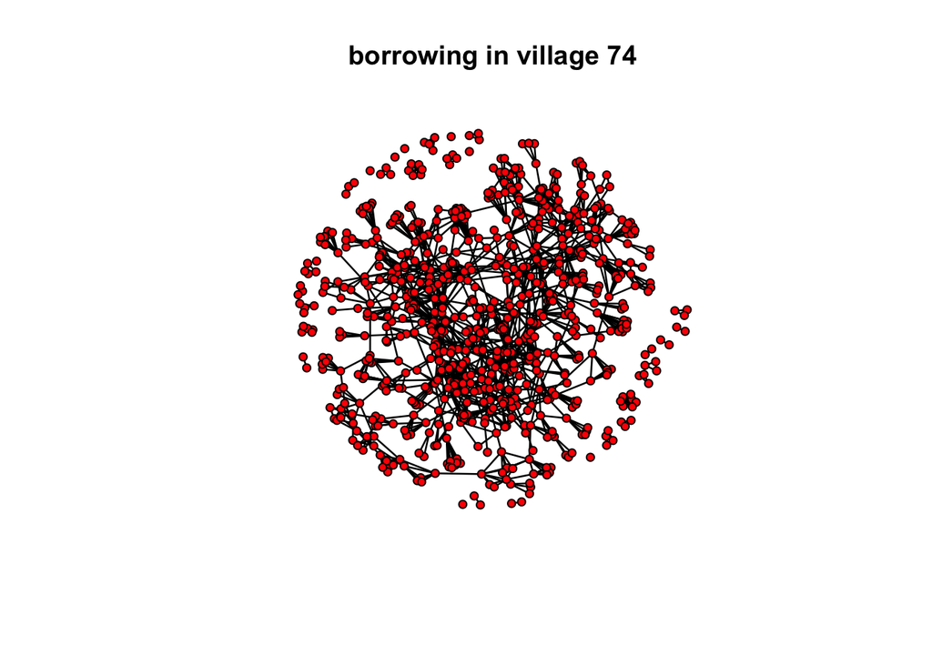

```r
#create a network object
net_bor_74 <- as.network(x = bor_money_74,
                         directed = FALSE,
                         loops = FALSE,
                         matrix.type = "adjacency")
#plot it (that looks pretty good)
plot(net_bor_74,
     main = "borrowing in village 74")
```

```r
#give them names (acc to their individual ids)
network.vertex.names(net_bor_74) <- ind_ids_74
```

Now I want to bring in covariate information.

```r
#reading in demographic data
indiv_data <- read.dta("/Users/Advait/Desktop/New_School/Fall17/Network_data/village_data/datav4.0/Data/2. Demographics and Outcomes/individual_characteristics.dta")
dim(indiv_data[indiv_data$village == 74,])
```

```
## [1] 193  48
```

We realize that a whole bunch of people have no info about the covariate measures, so we throw them out and make a new network. Biased? I think so.

```r
#look at their ids
good_people_74 <- indiv_data$pid[indiv_data$village == 74]
###I am starting over because of this data. tie individual ids to the adjacency matrix and drop those rows and columns
ind_ids_74$integer_ident <- seq(1:743)
#relevant people are ind_ids_74 with the missing data dropped
# ind_ids_74 <- ind_ids_74[,1:2]
good_ind_id_74 <- ind_ids_74[ind_ids_74$V1 %in% good_people_74,]
#now to select only the relevant rows and columns from borrow matrix
test <- as.matrix(bor_money_74)
test <- test[good_ind_id_74$integer_ident,good_ind_id_74$integer_ident]
dim(test)
```

```
## [1] 193 193
```

```r
net_good_bor_74 <- as.network(x = test,
                              directed = FALSE,
                              loops = FALSE,
                              matrix.type = "adjacency")
```

Look at the loss of information!

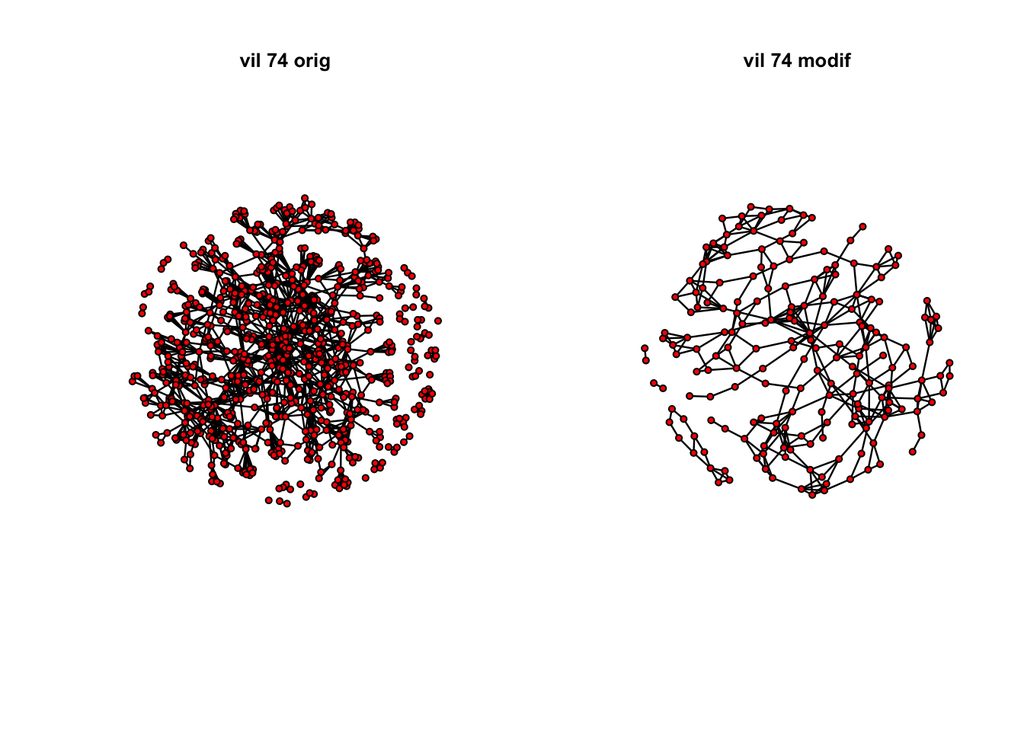

Make the good network, give the vertices attributes and so on, make it plot ready.

```r
####
#give the good network names
network.vertex.names(net_good_bor_74) <- good_ind_id_74$integer_ident
####Now I have a nice complete named network for VILL 74!

#explore attributes
#1. caste
caste_74 <- indiv_data$caste[indiv_data$village == 74]
length(caste_74)
```

```
## [1] 193
```

```r
set.vertex.attribute(net_good_bor_74,
                     "caste",
                     as.character(caste_74))
#2. religion
religion_74 <- indiv_data$religion[indiv_data$village == 74]
set.vertex.attribute(net_good_bor_74,
                     "religion",
                     as.character(religion_74))

#3. english
english_74 <- indiv_data$english[indiv_data$village == 74]
set.vertex.attribute(net_good_bor_74,
                     "english",
                     as.character(english_74))

#summarize network
summary.network(net_good_bor_74,
                print.adj = FALSE)
```

```
## Network attributes:
##   vertices = 193
##   directed = FALSE
##   hyper = FALSE
##   loops = FALSE
##   multiple = FALSE
##   bipartite = FALSE
##  total edges = 372
##    missing edges = 0
##    non-missing edges = 372
##  density = 0.02007772
##
## Vertex attributes:
##
##  caste:
##    character valued attribute
##    attribute summary:
##         GENERAL             OBC SCHEDULED CASTE SCHEDULED TRIBE
##               3             147              42               1
##
##  english:
##    character valued attribute
##    attribute summary:
##  No Yes
## 188   5
##
##  religion:
##    character valued attribute
##    attribute summary:
## HINDUISM    ISLAM
##      161       32
##   vertex.names:
##    character valued attribute
##    193 valid vertex names
##
## No edge attributes
```

## Plotting

- Degree distribution

```r
degreedist(net_good_bor_74)
```

```
##  degree1  degree2  degree3  degree4  degree5  degree6  degree7  degree8
##       10       38       49       34       30       13        9        7
##  degree9 degree10
##        2        1
```

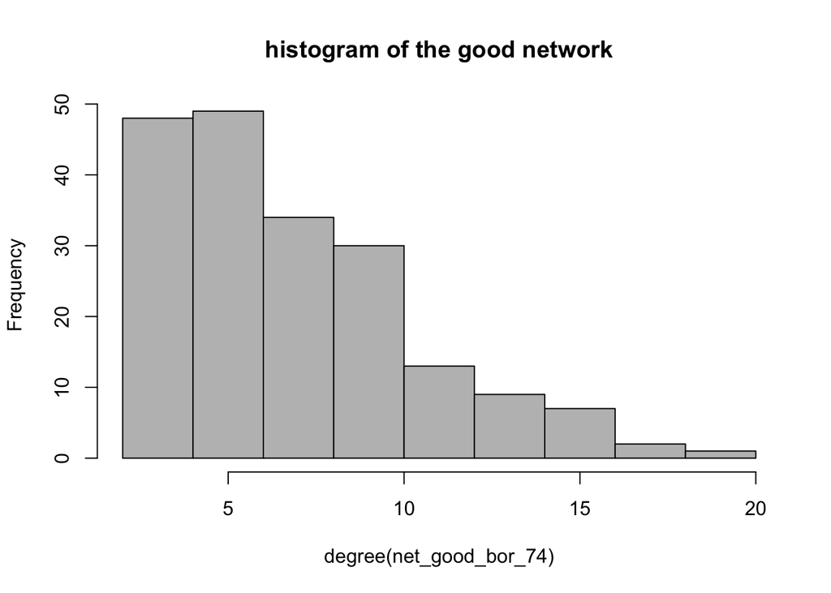

```r
hist(degree(net_good_bor_74),
     breaks = 12,
     col = "gray",
     main = "histogram of the good network")
```

- Caste plots

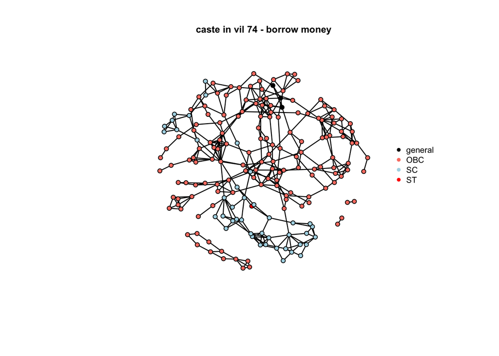

```r
#add colors based on attributes
#####
#Caste
#####
num_nodes <- 193
node_colors <- rep("",num_nodes)
for(i in 1:num_nodes){
  if(get.node.attr(net_good_bor_74,"caste")[i] == "GENERAL"){
    node_colors[i] <- "black"
  }
  if(get.node.attr(net_good_bor_74,"caste")[i] == "OBC"){
    node_colors[i] <- "salmon"
  }
  if(get.node.attr(net_good_bor_74,"caste")[i] == "SCHEDULED CASTE"){
    node_colors[i] <- "lightblue"
  }
  if(get.node.attr(net_good_bor_74,"caste")[i] == "SCHEDULED TRIBE"){
    node_colors[i] <- "red"
  }
}
#print(node_colors)

plot.network(net_good_bor_74, # our network object
             vertex.col = node_colors,
             displaylabels = F,
             main = "caste in vil 74 - borrow money",
             cex.main = 0.8)
legend(70,2,
       legend = c("general", "OBC", "SC", "ST"),
       col = c("black","salmon","lightblue","red"),
       pch = 16,
       bty = 'n',
       cex = 0.7)
```

- Religion plots

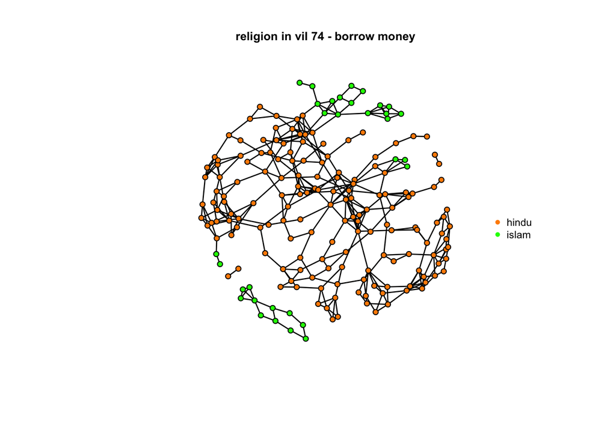

```r
#####
#Religion
#####
num_nodes <- 193
node_colors <- rep("",num_nodes)
for(i in 1:num_nodes){
  if(get.node.attr(net_good_bor_74,"religion")[i] == "HINDUISM"){
    node_colors[i] <- "darkorange"
  }
  if(get.node.attr(net_good_bor_74,"religion")[i] == "ISLAM"){
    node_colors[i] <- "green"
  }
}
#print(node_colors)

plot.network(net_good_bor_74,
             vertex.col = node_colors,
             displaylabels = F,
             main = "religion in vil 74 - borrow money",
             cex.main = 0.8)
legend(70,2,
       legend = c("hindu", "islam"),
       col = c("darkorange","green"),
       pch = 16,
       bty = 'n',
       cex = 0.7)
```

- English plots

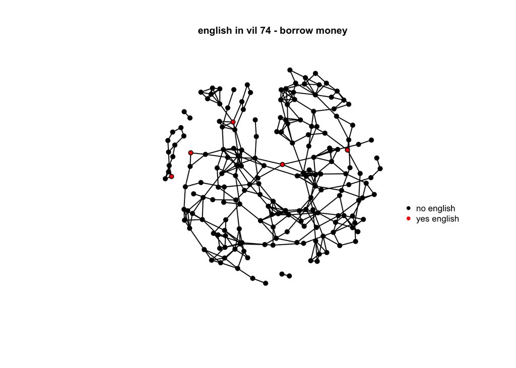

```r
#####
#English
#####
num_nodes <- 193
node_colors <- rep("",num_nodes)
for(i in 1:num_nodes){
  if(get.node.attr(net_good_bor_74,"english")[i] == "No"){
    node_colors[i] <- "black"
  }
  if(get.node.attr(net_good_bor_74,"english")[i] == "Yes"){
    node_colors[i] <- "red"
  }
}
#print(node_colors)

plot.network(net_good_bor_74,
             vertex.col = node_colors,
             displaylabels = F,
             main = "english in vil 74 - borrow money",
             cex.main = 0.8)
legend(70,2,
       legend = c("no english", "yes english"),
       col = c("black","red"),
       pch = 16,
       bty = 'n',
       cex = 0.7)
```

## Modeling

- ERGM

```r
#####
#trying ergm for vil 74
#####
model1_vil74 <- ergm(net_good_bor_74 ~ edges
                                     + nodematch('caste', diff = T)
                                     + nodematch('religion', diff = T)
                                     + nodematch('english', diff = T))
summary(model1_vil74)
```

```
##
## ==========================
## Summary of model fit
## ==========================
##
## Formula:   net_good_bor_74 ~ edges + nodematch("caste", diff = T) + nodematch("religion",
##     diff = T) + nodematch("english", diff = T)
##
## Iterations:  11 out of 20
##
## Monte Carlo MLE Results:
##                                   Estimate Std. Error MCMC % p-value
## edges                            -8.600426   0.487735      0  <1e-04 ***
## nodematch.caste.GENERAL          18.944198 252.254697      0   0.940
## nodematch.caste.OBC               2.435377   0.252078      0  <1e-04 ***
## nodematch.caste.SCHEDULED CASTE   3.464240   0.270746      0  <1e-04 ***
## nodematch.caste.SCHEDULED TRIBE       -Inf   0.000000      0  <1e-04 ***
## nodematch.religion.HINDUISM       2.812967   0.360259      0  <1e-04 ***
## nodematch.religion.ISLAM          3.860050   0.387158      0  <1e-04 ***
## nodematch.english.No              0.002746   0.251299      0   0.991
## nodematch.english.Yes                 -Inf   0.000000      0  <1e-04 ***
## ---
## Signif. codes:  0 '***' 0.001 '**' 0.01 '*' 0.05 '.' 0.1 ' ' 1
##
##      Null Deviance: 25685  on 18528  degrees of freedom
##  Residual Deviance:  3118  on 18519  degrees of freedom
##
## AIC: 3136    BIC: 3207    (Smaller is better.)
##
##  Warning: The following terms have infinite coefficient estimates:
##   nodematch.caste.SCHEDULED TRIBE nodematch.english.Yes
```

```r
#infinity coefficients are due to 0 within group ties
```

```r
#interpreting "edges"
expit = function(x) 1/(1+exp(-x))
expit(-8.7115)
```

```
## [1] 0.0001646539
```

```r
#logg odds of a tie converted to probability of a tie
```

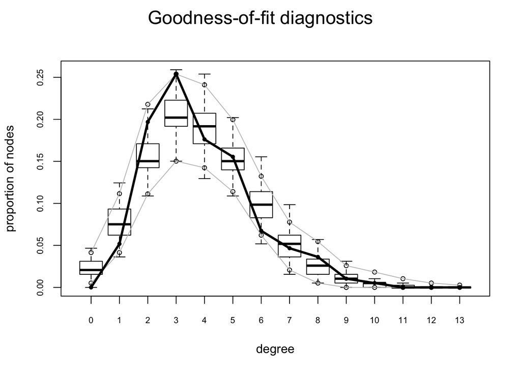

```r
#for degree
mod1_74_gof_deg <- gof(model1_vil74 ~ degree)
plot(mod1_74_gof_deg)
```

The black line is inside the gray lines. Good thing?

Note that I tried “triangle”" with the base configuration of ergm and that does not work!, So I go into ergm further controlling “interval size” and “sample size” etc.

[output not shown]

[output cut: 20 more lines]

```
##
## Fraction in 1st window = 0.1
## Fraction in 2nd window = 0.5
##
##              edges             kstar5    nodematch.caste
##             0.5428             0.1749             0.6677
## nodematch.religion  nodematch.english
##             0.2289             0.5960
##
## Individual P-values (lower = worse):
##              edges             kstar5    nodematch.caste
##          0.5872340          0.8611779          0.5043416
## nodematch.religion  nodematch.english
##          0.8189288          0.5511483
## Joint P-value (lower = worse):  0.7962362 .
```

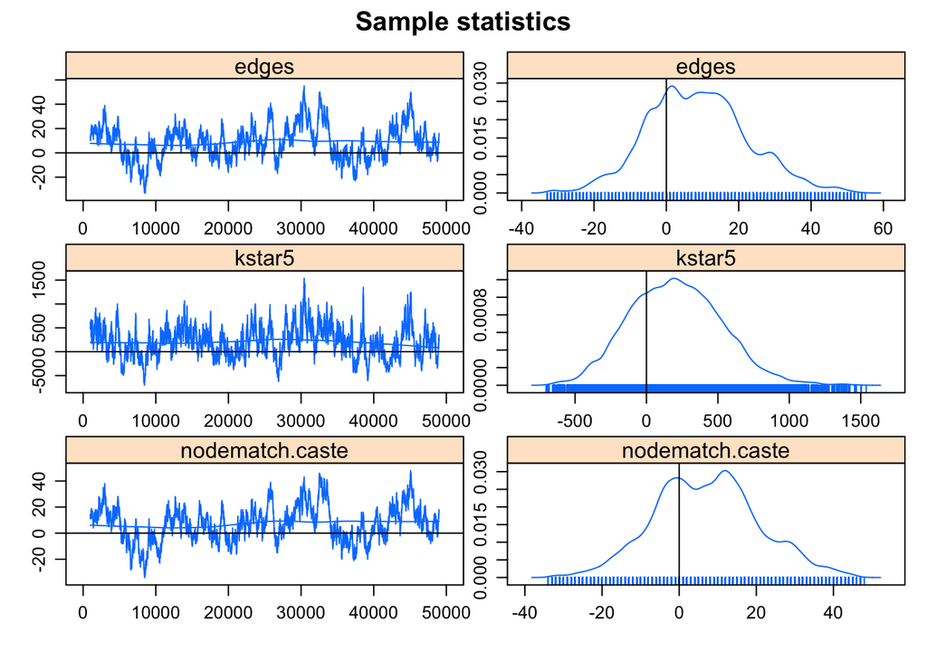

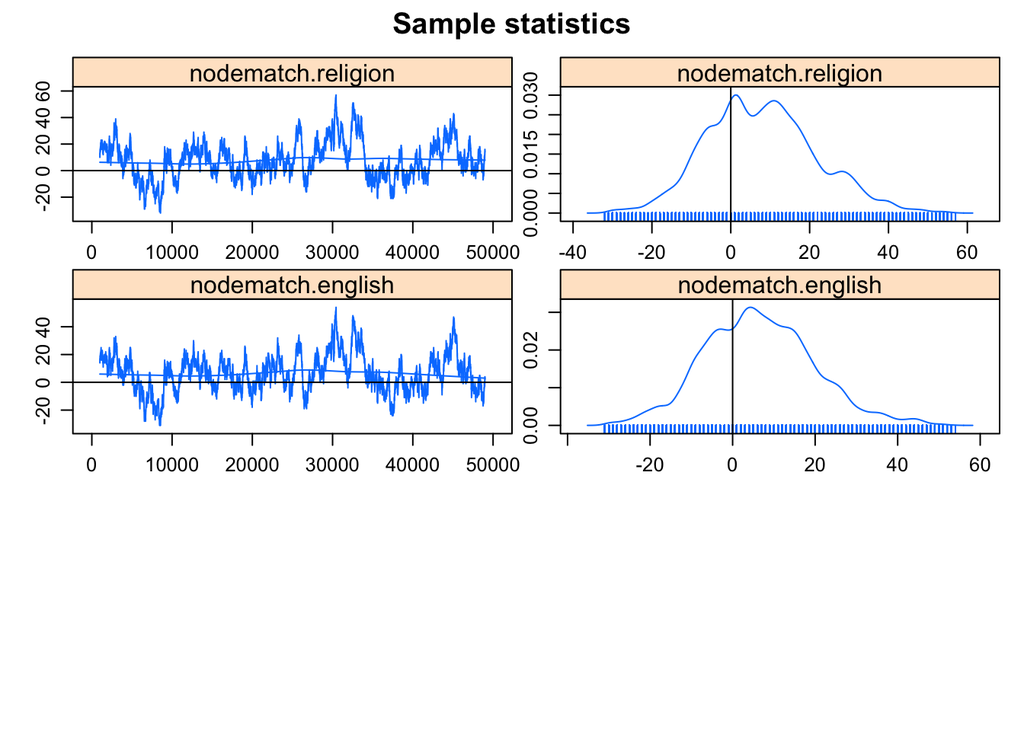

[output not shown]

```r
mod2_74 <- ergm(net_good_bor_74 ~ edges
                               + kstar(5)
                               + nodematch('caste', diff = F)
                               + nodematch('religion', diff = F)
                               + nodematch('english', diff = F) ,
                               control=control.ergm(MCMC.interval=1,
                               MCMC.burnin=1000,
                               MCMC.samplesize=12000,
                               seed=1))
plot(mod2_74)
```

- Bayesian ERGM

```r
#trying some Bayesian ergm
mod1_74_Bayes <- bergm(net_good_bor_74 ~ edges
                                       + triangle
                                       + kstar(5)
                                       + nodematch('caste', diff = F)
                                       + nodematch('religion', diff = F)
                                       + nodematch('english', diff = F) ,
                                       burn.in = 500,
                                       main.iters = 2000,
                                       aux.iters = 20000)
#something worked, giant output
#my instinct was confirmed and it is a multivariate normal prior the length (dimensions) of the number of predictors
```

Now we can monitor convergence

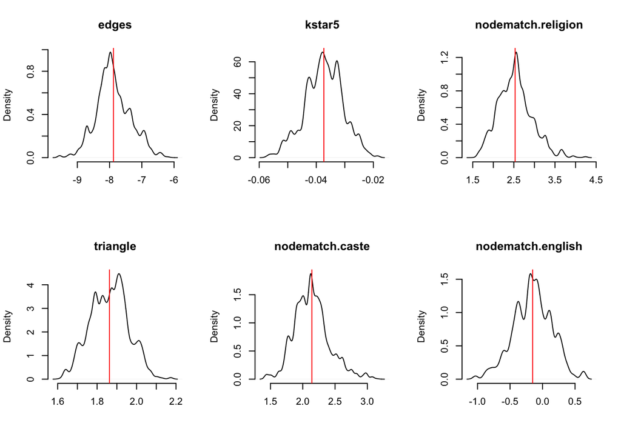

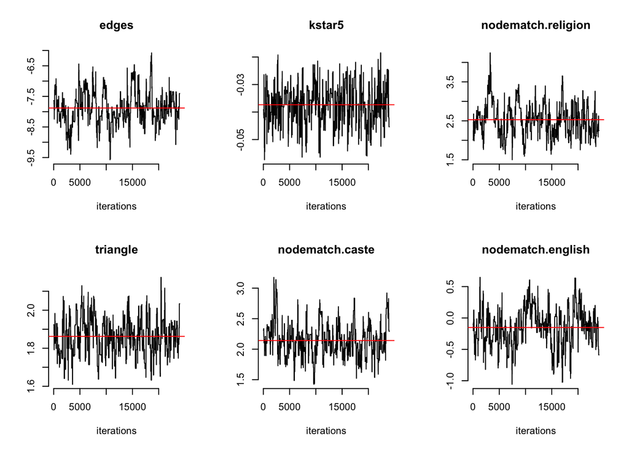